# rtry vignettes

## 3.10 `rtry_filter`

This function filters data from the input data based on the specified criteria and by default this filtering is performed based on the corresponding `ObservationID`. Therefore, if the column `ObservationID` has been removed, this function might not work (unless another attribute is defined when calling the function).

```r
rtry_filter(input = "", ..., baseOn = ObservationID, showOverview = TRUE)
```

| Argument | Description |
| --- | --- |
| `input` | Input data, imported by `rtry_import()` or in data table format |
| `...` | Criteria for filtering based on `ObservationID` |
| `baseOn` | Default `ObservationID`, the parameter used for filtering the data |
| `showOverview` | Default `TRUE` displays the dimension of data table after filtering |

**Example 1**

To filter juveniles while excluding the whole Observation.

First, check the `DataID` that contains information about plant development status, i.e. `413`, then check the different states of the `OrigValueStr` using the functions `rtry_select_row()` and `rtry_explore()`.

```r
tmp <- rtry_select_row(TRYdata, DataID %in% 413)
```

```r
## dim:    907 28
```

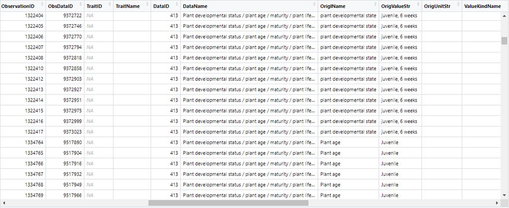

rtry_filter_usercase_1_01

```r
tmp1 <- rtry_explore(tmp, OrigValueStr, OriglName, OrigUnitStr, StdValue, Comment)
```

```r
## dim:    7 6
```

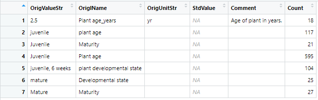

rtry_filter_usercase_1_02

Once the filtering criteria are identified, perform the filtering using `rtry_filter()`. It is also possible to simply this step by using `rtry_filter_keyword()` in which only the keywords such as `juvenile` needs to be specified to perform the filtering.

```r
tmp2 <- rtry_filter(tmp, (DataID %in% 413) & (OrigValueStr %in% c("2.5", "juvenile", "Juvenile", "juvenile, 6 weeks")))
```

```r
## dim:    52 28
```

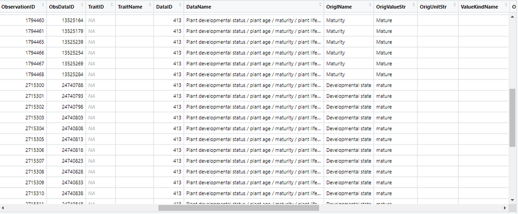

rtry_filter_usercase_1_03

```r
tmp3 <- rtry_explore(tmp2, OrigValueStr, OriglName, OrigUnitStr, StdValue, Comment)
```

```r
## dim:    2 6
```

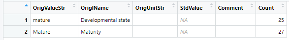

rtry_filter_usercase_1_04

Since the default value of `showOverview` are set to be `TRUE`, the dimension of data table after each step would be displayed in the console despite the argument `showOverview = TRUE` is not specified, and that the return data was assigned to the specified variables.

**Example 2**

To exclude the data with incorrect units, the parameter `ObsDataID` needs to be specified:

```r
tmp <- rtry_filter(TRYdata, (TraitID == 3116  & UnitName != "mm2 mg-1") |
                               (TraitID == 144  & UnitName != "mm") |
                               (TraitID == 3107  & UnitName != "m") |
                               (TraitID == 21  & UnitName != "m") |
                               (TraitID == 4  & UnitName != "g/cm3"), baseOn = ObsDataID, showOverview = FALSE)
```

Since the `showOverview` in this example is set to `FALSE`, the overview of the data would not be displayed in the console.

## 3.11 `rtry_filter_keyword`

This function filters data from the input data based on the specified keywords and the corresponding `ObservationID`. Therefore, if the column `ObservationID` has been removed, this function will not work.

```r
rtry_filter_keyword(
  input = "",
  attribute = NULL,
  ...,
  caseSensitive = TRUE,
  exactMatch = TRUE,
  showOverview = TRUE
)
```

| Argument | Description |
| --- | --- |
| `input` | Input data, imported by `rtry_import()` or in data table format |
| `attribute` | Attribute (column name) for filtering |
| `...` | Values (keywords) for filtering |
| `caseSensitive` | Default `TRUE` performs case-sensitive filtering |
| `exactMatch` | Default `TRUE` performs exact match filtering, overrides all conflicting arguments |
| `showOverview` | Default `TRUE` displays the dimension of data table after filtering |

**Example 1**

To filter juveniles while excluding the whole Observation.

First, check the `DataID` that contains information about plant development status, i.e. `413`, then check the different states of the `OrigValueStr` using the functions `rtry_select_row()` and `rtry_explore()`.

```r
tmp <- rtry_select_row(TRYdata, DataID %in% 413)
```

```r
## dim:    907 28
```

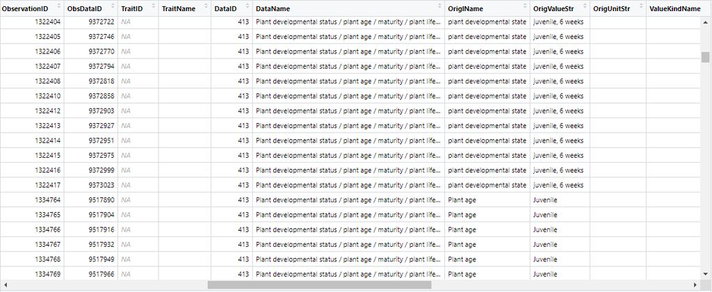

rtry_filter_usercase_1_01

```r
tmp1 <- rtry_explore(tmp, OrigValueStr, OriglName, OrigUnitStr, StdValue, Comment)
```

```r
## dim:    7 6
```

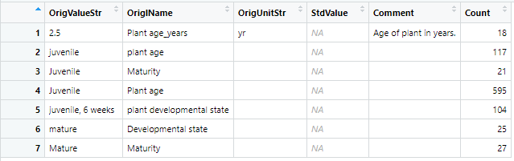

rtry_filter_usercase_1_02

Once the filtering criteria are identified, perform the filtering using `rtry_filter_keyword()`.

1. Manually enters the values for exact match (by default also case sensitive) filtering, which works as if `rtry_filter()` is used:

```r
tmp2 <- rtry_filter_keyword(tmp, OrigValueStr, c("2.5", "juvenile", "Juvenile", "juvenile, 6 weeks"))
```

```r
## dim:    52 28
```

2. Filtering with case-insensitive keywords:

```r
tmp3 <- rtry_filter_keyword(tmp, OrigValueStr, c("2.5", "juvenile"), caseSensitive = FALSE, exactMatch = FALSE)
```

```r
## dim:    52 28
```

Note that both (a) and (b) output the same results in this case, with only the data where `OrigValueStr` equals to `mature` or `Mature` remaining.

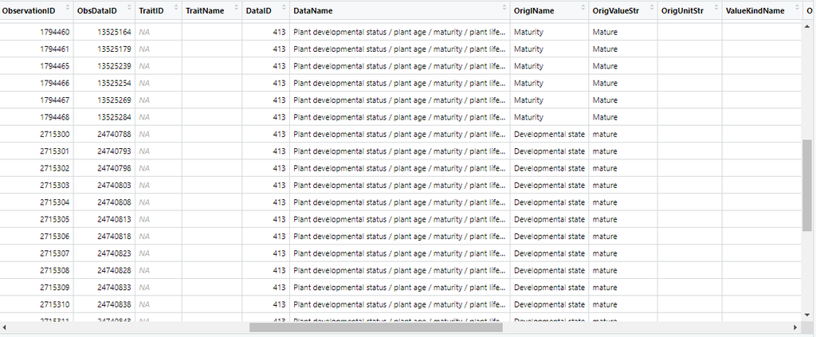

rtry_filter_usercase_1_03

```r
tmp4 <- rtry_explore(tmp3, OrigValueStr, OriglName, OrigUnitStr, StdValue, Comment)
```

```r
## dim:    2 6
```

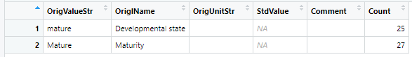

rtry_filter_usercase_1_04

Since the default value of `showOverview` are set to be `TRUE`, the dimension of data table after each step would be displayed in the console despite the argument `showOverview = TRUE` is not specified, and that the return data was assigned to the specified variables.

## 3.12 `rtry_rm_col`

This function removes the specified columns from the input data for further processing. This function can be viewed as an alternatives than `rtry_select_col()`.

```r
rtry_rm_col(input = "", ..., showOverview = TRUE)
```

| Argument | Description |
| --- | --- |
| `input` | Input data, imported by `rtry_import()` or in data table format |
| `...` | Column names to be removed |
| `showOverview` | Default `TRUE` displays the dimension of data table after removal |

**Example 1**

To remove the columns `LastName`, `FirstName`, `DatasetID`, `Dataset`, `SpeciesName`, `OrigUncertaintyStr`, `UncertaintyName`, `Replicates`, `RelUncertaintyPercent`, `Reference`, `V28` from `TRYdata`:

```r
TRYdata_rmColumns <- rtry_rm_col(TRYdata, LastName, FirstName, DatasetID, Dataset, SpeciesName, OrigUncertaintyStr, UncertaintyName, Replicates, RelUncertaintyPercent, Reference, V28)
```

```r
## dim:    435764 17
## col:   AccSpeciesID AccSpeciesName ObservationID ObsDataID TraitID TraitName DataID DataName OriglName OrigValueStr OrigUnitStr ValueKindName StdValue UnitName OrigObsDataID ErrorRisk Comment
```

Note that the resulting data table would be the same as in the example provided in `rtry_select_col()` in this case.

Since the default value of `showOverview` is set to be `TRUE`, the overview of the data after removal would be displayed in the console despite the argument `showOverview = TRUE` is not specified, and that the return data was assigned to the variable `TRYdata_rmColumns`.

## 3.13 `rtry_rm_dup`

This function identifies and removes the duplicates from the input data. Once the function is called and executed, the number of duplicates removed will be displayed on the console as reference.

Note that this function depends on the duplicate identifier `OrigObsDataID` listed in the TRYdata, therefore, if the column `OrigObsDataID` has been removed, this function will not work. Also, if the imported TRYdata contains restricted dataset that belongs to another dataset (i.e. having an `OrigObsDataID`), these restricted data will also be removed resulting in data loss.

```r
rtry_rm_dup(input = "", showOverview = TRUE)
```

| Argument | Description |
| --- | --- |
| `input` | Input data, imported by `rtry_import()` or in data table format |
| `showOverview` | Default `TRUE` displays the dimension of data table after removal |

**Example 1**

To remove the duplicates within `TRYdata_selectRow`:

```r
tmp_rmDuplicates <- rtry_rm_dup(TRYdata_selectRow)
```

```r
## 6726 duplicates removed.
## dim:    73192 17
```

Since the default value of `showOverview` is set to be `TRUE`, the dimension of data table after removal would be displayed in the console despite the argument `showOverview = TRUE` is not specified, and that the return data was assigned to the variable `tmp_rmDuplicates`.

## 3.14 `rtry_trans_wider`

This function transforms a long table into wide table, i.e. increasing the number of columns and decreasing the number of rows. For details, please refer to `tidyr::pivot_wider()`.

```r
rtry_trans_wider(
  input = "",
  names_from = NULL,
  values_from = NULL,
  values_fn = NULL,
  showOverview = TRUE
)
```

| Argument | Description |
| --- | --- |
| `input` | Input data, imported by `rtry_import()` or in data table format |
| `names_from` | The column(s) from which the output column names to be obtained |
| `values_from` | The column(s) from which the output values to be obtained |
| `values_fn` | (Optional) Function to be applied to the output values |
| `showOverview` | Default `TRUE` displays the dimension of the result data table |

## 3.15 `rtry_export`

This function exports the pre-processed data as a CSV file. If the specified output directory does not exist, it will be created.

```r
rtry_export(data = "", output = "", quote = TRUE, encoding = "UTF-8")
```

| Argument | Description |
| --- | --- |
| `data` | The data to be saved |
| `output` | Output path |
| `quote` | Default `TRUE` inserts double quotes around any character or factor columns |
| `encoding` | File encoding. Default `"UTF-8"` |

**Example 1**

To save the data `TRYdata1_explore` as `"output/Traits_auxilliary_Data_rtry.csv"`:

```r
rtry_export(TRYdata1_explore, "output/Traits_auxilliary_Data_rtry.csv")
```

```r
## New directory created at:  output
## File saved at:  output/Traits_auxilliary_Data_rtry.csv
```

Since the specified output directory does not exist in this case, it was created before saving the data into the CSV file.

## 3.16 `rtry_geocoding`

This function uses Nominatim, a search engine for OpenStreetMap data, to perform geocoding, i.e. converting an address into coordinates (latitudes, longitudes). For details, please refer to: https://wiki.openstreetmap.org/wiki/Nominatim.

```r
rtry_geocoding(address = NULL, email = NULL)
```

| Argument | Description |
| --- | --- |
| `address` | String of an address |
| `email` | String of an email address |

**Example 1**

To convert the address of MPI-BGC (`"Hans-Knoell-Strasse 10, 07745 Jena, Germany"`) into coordinates in latitudes and longitudes:

```r
rtry_geocoding("Hans-Knoell-Strasse 10, 07745 Jena, Germany", email = "jens.kattge@bgc-jena.mpg.de")
```

```r
##        lat      lon
## 1 50.91012 11.56674
```

An example workflow of how to use `rtry_geocoding()` for a list of locations or in a `.csv` file can be viewed in the vignette:

```r
vignette("rtry-workflow-geocoding")
```

## 3.17 `rtry_revgeocoding`

This function uses Nominatim, a search engine for OpenStreetMap data, to perform reverse geocoding, i.e. converting coordinates (latitudes, longitudes) into an address. For details, please refer to: https://wiki.openstreetmap.org/wiki/Nominatim.

```r
rtry_revgeocoding(lat_lon = NULL, email = NULL)
```

| Argument | Description |
| --- | --- |
| `lat_lon` | A data frame consisting latitude and longitude |
| `email` | String of an email address |

**Example 1**

To convert the coordinates (`data.frame(50.91012, 11.56674)`) into an address:

```r
rtry_revgeocoding(data.frame(50.91012, 11.56674), email = "jens.kattge@bgc-jena.mpg.de")
```

```r
##               full_address town city country country_code
## 1 Jena, Thuringia, Germany   NA Jena Germany           de
```

An example workflow of how to use `rtry_revgeocoding()` for a list of coordinates or in a `.csv` file can be viewed in the vignette:

```r
vignette("rtry-workflow-geocoding")
```

# 4 Data license

The TRY database is open source under a Creative Commons Attribution license (CC BY 4.0, https://creativecommons.org/licenses/by/4.0): anyone can use and redistribute data received via TRY under the only condition of appropriate citation of the TRY database and the references of contributing data sets.

The `rtry` package is also distributed under the CC BY 4.0 license, with a remark that the (reverse) geocoding functions provided within the package used the Nominatim developed with OpenStreetMap. Despite the API and the data provided are free to use for any purpose, including commercial use, note that they are governed by the ODbL (https://wiki.osmfoundation.org/wiki/Licence).

# 5 Authorship guidelines

The standard reference of the TRY database is currently:

Kattge, J., Bönisch, G., Díaz, S., Lavorel, S., Prentice, I. C., Leadley, P., Tautenhahn, S., Werner, G., et al. (2020). TRY plant trait database - enhanced coverage and open access. Global Change Biology, 26(1), 119-188. doi:10.1111/gcb.14904.